# Bioestadística

Variables Aleatorias y Distribuciones de Probabilidad

Giovany Babativa-Márquez, PhD

jgbabativam@unal.edu.co

# VARIABLES ALEATORIAS

## ¿Qué es una Variable Aleatoria?

### Definición formal

Una **variable aleatoria** $X$ es una función que asigna un valor numérico a cada resultado de un experimento aleatorio:

$$X : \Omega \longrightarrow \mathbb{R}$$

**Tip**

Cuando realizamos un ensayo de laboratorio, el resultado es incierto antes de hacerlo. La **variable aleatoria** es el mecanismo que convierte ese resultado en un número con el que podemos operar matemáticamente.

### Ejemplos en Ciencias Experimentales

| Experimento | Variable aleatoria $X$ | Valores posibles |
| --- | --- | --- |
| Pesar una muestra en la balanza analítica | Peso (g) | $[0, +\infty)$ |
| Sembrar una placa de Petri | Número de colonias bacterianas | $0, 1, 2, \ldots$ |
| Realizar una reacción química | Tiempo de reacción (min) | $(0, +\infty)$ |
| Aplicar una prueba de control de calidad | Resultado (aprobado/rechazado) | $\{0, 1\}$ |
| Monitorear un lote de producción | Unidades defectuosas | $0, 1, \ldots, n$ |

## Tipos de Variables Aleatorias

### Discreta

Toma valores **contables** (finitos o infinito numerable):

$$X \in \{x_1, x_2, x_3, \ldots\}$$

**Ejemplos experimentales:**

- Número de colonias bacterianas en una placa
- Número de tabletas defectuosas por lote
- Conteo de eventos de contaminación por semana

### Continua

Toma valores en un **intervalo** de $\mathbb{R}$ (infinito no numerable):

$$X \in (a, b) \subseteq \mathbb{R}$$

**Ejemplos experimentales:**

- Concentración de un analito (mg/L)
- pH de una disolución
- Peso de una muestra (g)
- Tiempo de reacción (horas)

## Ejemplo: Discreta o continua?

En una campaña de muestreo ambiental se registran varias variables. Clasifiquémoslas:

- Número de macroinvertebrados capturados en una red de arrastre $\rightarrow$ toma valores $0,1,2,\ldots$ $\Rightarrow$ **discreta**
- Concentración de oxígeno disuelto en el agua (mg/L) $\rightarrow$ toma cualquier valor en un intervalo $\Rightarrow$ **continua**
- Número de especies vegetales identificadas en una parcela $\rightarrow$ conteo $\Rightarrow$ **discreta**
- Profundidad (m) a la que se encuentra una capa rocosa $\rightarrow$ intervalo de $\mathbb{R}$ $\Rightarrow$ **continua**

## Tu turno: Discreta o continua?

**Tu turno**

Para cada variable, indica si es **discreta** o **continua** y justifica en una frase.

**Ejercicio 1.** Un laboratorio de farmacia registra:

1. El número de comprimidos rotos en una caja de 100.
2. La concentración de un excipiente en una solución (mg/mL).
3. El número de pacientes que reportan un efecto adverso en un ensayo clínico.

**Ejercicio 2.** Un geólogo en campo registra:

1. El pH de una muestra de agua subterránea.
2. El número de fósiles encontrados en un estrato.
3. La masa (g) de un mineral extraído.

## Solución

**Ejercicio 1**

1. Discreta (conteo: $0,1,\ldots,100$) $\quad$ b) Continua (intervalo de $\mathbb{R}^+$) $\quad$ c) Discreta (conteo)

**Ejercicio 2**

1. Continua (intervalo de $\mathbb{R}^+$) $\quad$ b) Discreta (conteo) $\quad$ c) Continua (intervalo de $\mathbb{R}^+$)

## Función de Distribución Acumulada (FDA)

### Definición

Para cualquier variable aleatoria $X$ (discreta o continua), la **función de distribución acumulada** es:

$$\boxed{F(x) = P(X \leq x), \quad x \in \mathbb{R}}$$

### Propiedades

- $0 \leq F(x) \leq 1$ para todo $x$
- $F$ es **no decreciente**: si $a < b$ entonces $F(a) \leq F(b)$
- $\displaystyle\lim_{x \to -\infty} F(x) = 0$ y $\displaystyle\lim_{x \to +\infty} F(x) = 1$
- $P(a < X \leq b) = F(b) - F(a)$

## Ejemplo: FDA de partículas contaminantes

En un filtro de agua se cuenta el número $X$ de partículas contaminantes retenidas, con función de probabilidad:

| $x$ | 0 | 1 | 2 | 3 | 4 |
| --- | --- | --- | --- | --- | --- |
| $p(x)$ | 0.10 | 0.30 | 0.35 | 0.15 | 0.10 |

**Construyendo la FDA:**

| $x$ | 0 | 1 | 2 | 3 | 4 |
| --- | --- | --- | --- | --- | --- |
| $F(x)$ | 0.10 | 0.40 | 0.75 | 0.90 | 1.00 |

$P(X > 2) = 1 - F(2) = 1 - 0.75 = \mathbf{0.25}$ $P(1 < X \leq 3) = F(3) - F(1) = 0.90 - 0.40 = \mathbf{0.50}$

## Tu turno: Calculando la FDA

**Tu turno**

**Ejercicio 1.** En una parcela de muestreo se registra el número $X$ de suelos que exceden un umbral de contaminación (de 4 evaluados):

| $x$ | 0 | 1 | 2 | 3 | 4 |
| --- | --- | --- | --- | --- | --- |
| $p(x)$ | 0.20 | 0.35 | 0.25 | 0.15 | 0.05 |

Construye $F(x)$ y calcula $P(X > 2)$ y $P(1 < X \leq 3)$.

**Ejercicio 2.** El número $X$ de brotes florales dañados por granizo en una planta tiene:

| $x$ | 0 | 1 | 2 | 3 |
| --- | --- | --- | --- | --- |
| $p(x)$ | 0.45 | 0.30 | 0.15 | 0.10 |

Construye $F(x)$ y calcula $P(X \geq 2)$ y $P(X < 3)$.

## Solución

**Ejercicio 1:**

| $x$ | 0 | 1 | 2 | 3 | 4 |
| --- | --- | --- | --- | --- | --- |
| $F(x)$ | 0.20 | 0.55 | 0.80 | 0.95 | 1.00 |

$$P(X > 2) = 1 - F(2) = 1 - 0.80 = \mathbf{0.20}$$

$$P(1 < X \leq 3) = F(3) - F(1) = 0.95 - 0.55 = \mathbf{0.40}$$

**Ejercicio 2:**

| $x$ | 0 | 1 | 2 | 3 |
| --- | --- | --- | --- | --- |
| $F(x)$ | 0.45 | 0.75 | 0.90 | 1.00 |

$$P(X \geq 2) = 1 - F(1) = 1 - 0.75 = \mathbf{0.25} \qquad P(X < 3) = F(2) = \mathbf{0.90}$$

# VARIABLES DISCRETAS

## Función de Probabilidad Puntual (FPP)

### Definición

Para una variable aleatoria discreta $X$, la **función de probabilidad puntual** se define como:

$$\boxed{p(x) = P(X = x)}$$

### Propiedades

1. $p(x) \geq 0$, $\forall x$
2. $\displaystyle\sum_{x} p(x) = 1$
3. $P(X \in A) = \displaystyle\sum_{x \in A} p(x)$

## Ejemplo: Tabletas defectuosas por lote

En una línea de producción farmacéutica se registra el número de **tabletas defectuosas** $X$ detectadas durante un lote de producción de 8 horas:

| $x$ | 0 | 1 | 2 | 3 | 4 |
| --- | --- | --- | --- | --- | --- |
| $p(x)$ | 0.30 | 0.35 | 0.20 | 0.10 | 0.05 |

**Verificación:**

$$\sum p(x) = 0.30 + 0.35 + 0.20 + 0.10 + 0.05 = 1 \checkmark$$

### Cálculo de probabilidades

Con la distribución de tabletas defectuosas:

$$P(X \geq 2) = p(2) + p(3) + p(4) = 0.20 + 0.10 + 0.05 = \mathbf{0.35}$$

$$P(1 \leq X \leq 3) = p(1) + p(2) + p(3) = 0.35 + 0.20 + 0.10 = \mathbf{0.65}$$

$$P(X < 2) = p(0) + p(1) = 0.30 + 0.35 = \mathbf{0.65}$$

## Representación gráfica de la FPP

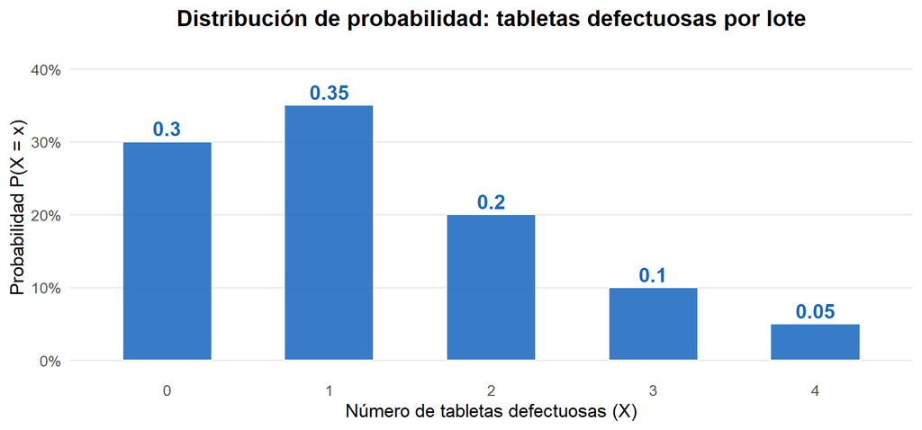

## Tu turno: Función de probabilidad puntual

**Tu turno**

**Ejercicio 1.** De 3 semillas sembradas de un lote, el número $X$ de semillas viables tiene función de probabilidad:

| $x$ | 0 | 1 | 2 | 3 |
| --- | --- | --- | --- | --- |
| $p(x)$ | 0.05 | 0.20 | 0.35 | 0.40 |

Verifica que es una FPP válida y calcula $P(X \geq 2)$ y $P(X \leq 1)$.

**Ejercicio 2.** En una roca se identifica el número $X$ de tipos de minerales presentes:

| $x$ | 0 | 1 | 2 | 3 | 4 |
| --- | --- | --- | --- | --- | --- |
| $p(x)$ | 0.02 | 0.18 | 0.40 | 0.30 | 0.10 |

Calcula $P(X = 3)$, $P(1 \leq X \leq 3)$ y $P(X > 2)$.

## Solución

**Ejercicio 1:** $\sum p(x) = 0.05+0.20+0.35+0.40 = 1\ \checkmark$

$$P(X \geq 2) = 0.35 + 0.40 = \mathbf{0.75} \qquad P(X \leq 1) = 0.05 + 0.20 = \mathbf{0.25}$$

**Ejercicio 2:**

$$P(X = 3) = \mathbf{0.30}$$

$$P(1 \leq X \leq 3) = 0.18+0.40+0.30 = \mathbf{0.88}$$

$$P(X > 2) = 0.30+0.10 = \mathbf{0.40}$$

# VARIABLES CONTINUAS

## Función de Densidad de Probabilidad (FDP)

### Definición

Para una variable aleatoria continua $X$, la **función de densidad de probabilidad** $f(x)$ satisface:

$$\boxed{P(a \leq X \leq b) = \int_a^b f(x)\, dx}$$

### Propiedades

1. $f(x) \geq 0$ para todo $x$
2. $\displaystyle\int_{-\infty}^{+\infty} f(x)\, dx = 1$
3. **Importante:** $P(X = x) = 0$ para cualquier valor puntual
4. $P(a < X < b) = P(a \leq X \leq b) = F(b) - F(a)$

## Interpretación gráfica

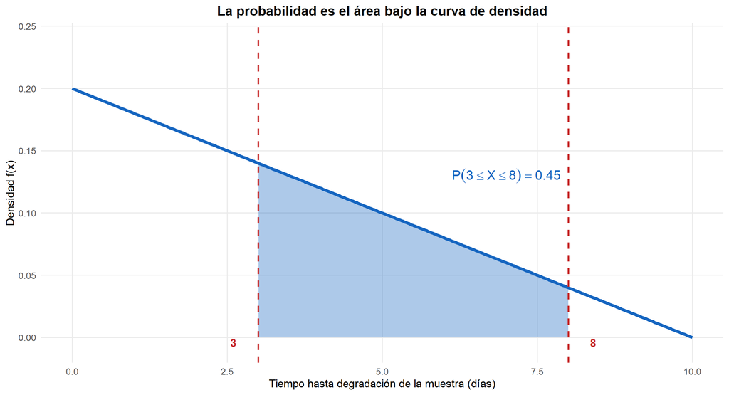

## Ejemplo: Degradación de una muestra

El tiempo $X$ (días) hasta que una muestra biológica refrigerada muestra signos de degradación tiene densidad:

$$f(x) = \frac{10 - x}{50}, \quad 0 < x < 10 \qquad \text{Primitiva: } \int (10 - x)\,dx = 10x - \frac{x^2}{2}$$

**¿Probabilidad de que se degrade en menos de 3 días?**

$$P(X < 3) = \frac{1}{50}\left[10x - \frac{x^2}{2}\right]_0^3 = \frac{30 - 4.5}{50} = \mathbf{0.51}$$

**¿Y entre 5 y 10 días?**

$$P(5 < X < 10) = \frac{1}{50}\left[10x - \frac{x^2}{2}\right]_5^{10} = \frac{50 - 37.5}{50} = \mathbf{0.25}$$

## Tu turno: Función de densidad

**Tu turno**

**Ejercicio 1.** El tiempo adicional $X$ (minutos) que tarda un reactivo en alcanzar la temperatura de trabajo sigue una densidad **uniforme**:

$$f(x) = \frac{1}{10}, \quad 0 < x < 10$$

Calcula $P(2 < X < 5)$ y $P(X > 8)$.

**Ejercicio 2.** El tamaño de grano $X$ (mm) de un sedimento en cierto yacimiento sigue la densidad:

$$f(x) = \frac{x}{8}, \quad 0 < x < 4$$

Verifica que $\int_0^4 f(x)\,dx = 1$ y calcula $P(X < 2)$ y $P(1 < X < 3)$.

## Solución

**Ejercicio 1:**

$$P(2 < X < 5) = \int_2^5 \frac{1}{10}\,dx = \frac{5-2}{10} = \mathbf{0.30}$$

$$P(X > 8) = \int_8^{10} \frac{1}{10}\,dx = \frac{2}{10} = \mathbf{0.20}$$

**Ejercicio 2:** $\displaystyle\int_0^4 \frac{x}{8}\,dx = \left.\frac{x^2}{16}\right|_0^4 = \frac{16}{16} = 1\ \checkmark$

$$P(X<2) = \int_0^2 \frac{x}{8}\,dx = \frac{4}{16} = \mathbf{0.25}$$

$$P(1<X<3) = \int_1^3 \frac{x}{8}\,dx = \frac{9-1}{16} = \mathbf{0.50}$$

# VALOR ESPERADO

## Definición: Valor Esperado

El **valor esperado** (o media) de una variable aleatoria $X$ mide su valor promedio en el largo plazo.

### Variable discreta

$$\boxed{E[X] = \sum_{x} x \cdot p(x)}$$

### Variable continua

$$\boxed{E[X] = \int_{-\infty}^{+\infty} x \cdot f(x)\, dx}$$

> **Interpretación:** Si observamos el mismo proceso experimental muchas veces, $E[X]$ es el promedio de los resultados que obtendríamos.

## Ejemplo: Tabletas defectuosas

Retomando la distribución de tabletas defectuosas por lote:

| $x$ | 0 | 1 | 2 | 3 | 4 |
| --- | --- | --- | --- | --- | --- |
| $p(x)$ | 0.30 | 0.35 | 0.20 | 0.10 | 0.05 |

$$E[X] = 0(0.30) + 1(0.35) + 2(0.20) + 3(0.10) + 4(0.05)$$

$$E[X] = 0 + 0.35 + 0.40 + 0.30 + 0.20 = \mathbf{1.25}$$

**Interpretación:** En promedio se producen **1.25 tabletas defectuosas** por lote de producción de 8 horas.

## Ejemplo: Valor esperado de una variable continua

El tiempo de reacción $X$ (minutos) de una enzima sigue una distribución **uniforme** entre 2 y 6 minutos:

$$f(x) = \frac{1}{4}, \quad 2 < x < 6$$

$$E[X] = \int_{2}^{6} x \cdot \frac{1}{4}\, dx = \frac{1}{4}\left[\frac{x^2}{2}\right]_2^6 = \frac{1}{4}(18 - 2) = \mathbf{4} \text{ minutos}$$

**Interpretación:** Coincide con el punto medio del intervalo, $\frac{2+6}{2} = 4$, como es de esperarse en una distribución uniforme.

## Propiedades del Valor Esperado

Sea $X$, $Y$ variables aleatorias y $a$, $b$ constantes:

1. $E[a] = a$
2. $E[aX] = a \cdot E[X]$
3. $E[X + b] = E[X] + b$
4. **Linealidad:** $E[aX + b] = a \cdot E[X] + b$
5. **Aditividad:** $E[X + Y] = E[X] + E[Y]$ (siempre)
6. Si $X$ e $Y$ son independientes: $E[XY] = E[X] \cdot E[Y]$

### Aplicación experimental: Transformación de escala

La **concentración de un analito** en una muestra tiene $E[C] = 72$ mg/L.

Si medimos en otra escala (por ejemplo, tras una dilución y un ajuste): $C^* = 0.5 \cdot C + 10$:

$$E[C^*] = 0.5 \cdot E[C] + 10 = 0.5 \cdot 72 + 10 = \mathbf{46}$$

Si registramos la **suma** de concentraciones de 3 muestras:

$$E[C_1 + C_2 + C_3] = E[C_1] + E[C_2] + E[C_3] = 72 + 72 + 72 = \mathbf{216}$$

## Tu turno: Valor esperado

**Tu turno**

**Ejercicio 1.** De una camada de 3 crías, el número $X$ que sobrevive tiene:

| $x$ | 0 | 1 | 2 | 3 |
| --- | --- | --- | --- | --- |
| $p(x)$ | 0.10 | 0.25 | 0.35 | 0.30 |

Calcula $E[X]$.

**Ejercicio 2.** Una variable $X \in (0,1)$ tiene densidad $f(x) = 3x^2$.

Calcula $E[X]$.

## Solución

**Ejercicio 1:**

$$E[X] = 0(0.10)+1(0.25)+2(0.35)+3(0.30)$$

$$E[X] = 0+0.25+0.70+0.90 = \mathbf{1.85} \text{ crías}$$

**Ejercicio 2:**

$$E[X] = \int_0^1 x \cdot 3x^2\, dx = \int_0^1 3x^3\, dx = \left.\frac{3x^4}{4}\right|_0^1 = \mathbf{0.75}$$

# VARIANZA Y DESVIACIÓN ESTÁNDAR

## Definición: Varianza

La **varianza** mide la dispersión de $X$ alrededor de su media $\mu = E[X]$:

$$\boxed{Var(X) = E\left[(X - \mu)^2\right]}$$

### Fórmula de cálculo (equivalente y más práctica)

$$\boxed{Var(X) = E[X^2] - (E[X])^2}$$

### Desviación estándar

$$\sigma_X = \sqrt{Var(X)}$$

La desviación estándar tiene las **mismas unidades** que $X$, lo que facilita su interpretación experimental.

## Ejemplo: Varianza de tabletas defectuosas

| $x$ | $p(x)$ | $x^2$ | $x^2 \cdot p(x)$ |
| --- | --- | --- | --- |
| 0 | 0.30 | 0 | 0.000 |
| 1 | 0.35 | 1 | 0.350 |
| 2 | 0.20 | 4 | 0.800 |
| 3 | 0.10 | 9 | 0.900 |
| 4 | 0.05 | 16 | 0.800 |

$$E[X^2] = 2.850$$

$$Var(X) = 2.850 - (1.25)^2 = 2.850 - 1.5625 = \mathbf{1.2875}$$

$$\sigma_X = \sqrt{1.2875} \approx \mathbf{1.13} \text{ tabletas defectuosas}$$

## Ejemplo: Varianza de una variable continua

Retomando el tiempo de reacción enzimática $X \sim \text{Unif}(2,6)$, con $f(x) = \frac{1}{4}$ y $E[X] = 4$:

$$E[X^2] = \int_{2}^{6} x^2 \cdot \frac{1}{4}\, dx = \frac{1}{4}\left[\frac{x^3}{3}\right]_2^6 = \frac{1}{4}\left(\frac{216-8}{3}\right) = \mathbf{17.33}$$

$$Var(X) = E[X^2] - (E[X])^2 = 17.33 - 4^2 = \mathbf{1.33}$$
$$\sigma_X = \sqrt{1.33} \approx \mathbf{1.15} \text{ min}$$

## Propiedades de la Varianza

Sean $X$, $Y$ variables aleatorias, $a$, $b$ constantes:

1. $Var(b) = 0$
2. $Var(X + b) = Var(X)$
3. $Var(aX) = a^2 \cdot Var(X)$
4. **Lineal:** $Var(aX + b) = a^2 \cdot Var(X)$
5. Si $X$ e $Y$ son **independientes**:
   $$Var(X + Y) = Var(X) + Var(Y)$$

> **Nota:** En general, $Var(X + Y) = Var(X) + Var(Y) + 2\,Cov(X,Y)$

## Tu turno: Varianza

**Tu turno**

**Ejercicio 1.** Retomando la variable “número de crías que sobreviven” ($E[X]=1.85$):

| $x$ | 0 | 1 | 2 | 3 |
| --- | --- | --- | --- | --- |
| $p(x)$ | 0.10 | 0.25 | 0.35 | 0.30 |

Calcula $Var(X)$ y $\sigma_X$.

**Ejercicio 2.** Retomando $X \in (0,1)$ con $f(x) = 3x^2$ ($E[X]=0.75$), calcula $Var(X)$ y $\sigma_X$.

## Solución

**Ejercicio 1:** $E[X^2] = 0^2(0.10)+1^2(0.25)+2^2(0.35)+3^2(0.30) = 0.25+1.40+2.70 = 4.35$

$$Var(X) = 4.35 - (1.85)^2 = 4.35 - 3.4225 = \mathbf{0.9275}$$

$$\sigma_X \approx \mathbf{0.96} \text{ crías}$$

**Ejercicio 2:** $\displaystyle E[X^2] = \int_0^1 x^2\cdot 3x^2\,dx = \int_0^1 3x^4\,dx = \left.\frac{3x^5}{5}\right|_0^1 = 0.6$

$$Var(X) = 0.6 - (0.75)^2 = 0.6 - 0.5625 = \mathbf{0.0375}$$

$$\sigma_X \approx \mathbf{0.19}$$

# COVARIANZA Y CORRELACIÓN

## Definición: Covarianza

La **covarianza** mide la relación lineal entre dos variables aleatorias $X$ e $Y$:

$$\boxed{Cov(X,Y) = E\left[(X - \mu_X)(Y - \mu_Y)\right] = E[XY] - E[X]\cdot E[Y]}$$

| Valor de $Cov(X,Y)$ | Interpretación |
| --- | --- |
| $> 0$ | Cuando $X$ aumenta, $Y$ tiende a **aumentar** |
| $< 0$ | Cuando $X$ aumenta, $Y$ tiende a **disminuir** |
| $= 0$ | No hay relación lineal (puede haber relación no lineal) |

## Correlación de Pearson

La covarianza depende de las unidades. El **coeficiente de correlación** estandariza:

$$\boxed{\rho_{XY} = \frac{Cov(X,Y)}{\sigma_X \cdot \sigma_Y}, \quad -1 \leq \rho \leq 1}$$

| $\rho$ | Interpretación |
| --- | --- |
| $\approx 1$ | Relación lineal positiva fuerte |
| $\approx -1$ | Relación lineal negativa fuerte |
| $\approx 0$ | Sin relación lineal |

## Ejemplo: Cálculo manual con pocos datos

Se mide la temperatura del agua $X$ (°C) y la frecuencia respiratoria $Y$ (resp/min) de un pez en 5 acuarios:

| $X$ | 18 | 20 | 22 | 24 | 26 |
| --- | --- | --- | --- | --- | --- |
| $Y$ | 45 | 50 | 54 | 60 | 65 |

$\bar{X} = 22 \qquad \bar{Y} = 54.8$

| $x-\bar{X}$ | -4 | -2 | 0 | 2 | 4 |
| --- | --- | --- | --- | --- | --- |
| $y-\bar{Y}$ | -9.8 | -4.8 | -0.8 | 5.2 | 10.2 |
| producto | 39.2 | 9.6 | 0 | 10.4 | 40.8 |

## Solución del ejemplo

$$\sum (x-\bar{X})(y-\bar{Y}) = 39.2+9.6+0+10.4+40.8 = 100$$

$$Cov(X,Y) = \frac{100}{5} = \mathbf{20}$$

$$\sigma_X = \sqrt{\frac{(-4)^2+(-2)^2+0^2+2^2+4^2}{5}} = \sqrt{8} \approx 2.83 \qquad \sigma_Y = \sqrt{50.16} \approx 7.08$$

$$\rho_{XY} = \frac{20}{2.83 \times 7.08} \approx \mathbf{0.998}$$

**Interpretación:** Relación lineal positiva casi perfecta: a mayor temperatura, mayor frecuencia respiratoria.

## Verificación en R

```r
Temp <- c(18, 20, 22, 24, 26)
FrecResp <- c(45, 50, 54, 60, 65)

# cov() y cor() en R usan la fórmula muestral (dividen por n-1)
cov(Temp, FrecResp)
```

```
[1] 25
```

```r
cor(Temp, FrecResp)
```

```
[1] 0.9984038
```

> `cov()` da 25 (no 20) porque R divide por $n-1=4$ en vez de $n=5$. La **correlación** no se ve afectada, pues el factor se cancela.

## Ejemplo: Dosis de fertilizante y altura de la planta

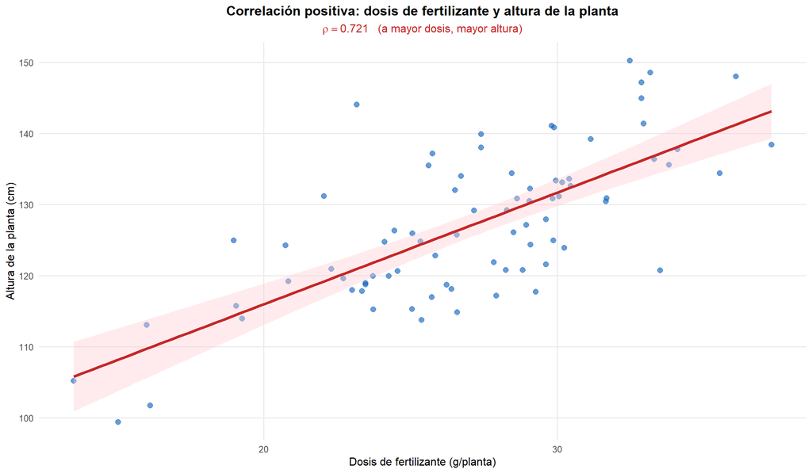

## Tu turno: Covarianza y correlación

**Tu turno**

**Ejercicio 1.** Se mide la distancia $X$ (km) a una fuente de vertimiento y la concentración de nitratos $Y$ (mg/L) en 5 puntos del río:

| $X$ | 1 | 2 | 3 | 4 | 5 |
| --- | --- | --- | --- | --- | --- |
| $Y$ | 40 | 32 | 25 | 18 | 10 |

Calcula (a mano) $Cov(X,Y)$ y $\rho_{XY}$. Verifica con `cov()`/`cor()` en R.

**Ejercicio 2.** Se mide la dosis $X$ (mg) de un fármaco y el tiempo de reacción $Y$ (seg) de un paciente en 5 ensayos:

| $X$ | 2 | 4 | 6 | 8 | 10 |
| --- | --- | --- | --- | --- | --- |
| $Y$ | 30 | 26 | 20 | 15 | 9 |

Calcula (a mano) $Cov(X,Y)$ y $\rho_{XY}$.

## Solución: Ejercicio 1

$\bar{X}=3, \ \bar{Y}=25$. Desviaciones $x-\bar{X}$: $-2,-1,0,1,2$; $\ y-\bar{Y}$: $15,7,0,-7,-15$

$$\sum(x-\bar{X})(y-\bar{Y}) = -30-7+0-7-30 = -74$$

$$Cov(X,Y) = \frac{-74}{5} = \mathbf{-14.8}$$

$$\sigma_X = \sqrt{2} \approx 1.41 \qquad \sigma_Y \approx 10.47$$

$$\rho_{XY} = \frac{-14.8}{1.41 \times 10.47} \approx \mathbf{-1.00}$$

Relación lineal **negativa casi perfecta**: a mayor distancia, menor concentración de nitratos.

```r
Dist <- c(1,2,3,4,5); Nitratos <- c(40,32,25,18,10)
cov(Dist, Nitratos); cor(Dist, Nitratos)
```

```
[1] -18.5
```

```
[1] -0.999635
```

## Solución: Ejercicio 2

$\bar{X}=6, \ \bar{Y}=20$. Desviaciones $x-\bar{X}$: $-4,-2,0,2,4$; $\ y-\bar{Y}$: $10,6,0,-5,-11$

$$\sum(x-\bar{X})(y-\bar{Y}) = -40-12+0-10-44 = -106$$

$$Cov(X,Y) = \frac{-106}{5} = \mathbf{-21.2}$$

$$\sigma_X = \sqrt{8} \approx 2.83 \qquad \sigma_Y \approx 7.51$$

$$\rho_{XY} = \frac{-21.2}{2.83 \times 7.51} \approx \mathbf{-0.998}$$

Relación lineal negativa fuerte: a mayor dosis, menor tiempo de reacción.

```r
Dosis <- c(2,4,6,8,10); Tiempo <- c(30,26,20,15,9)
cov(Dosis, Tiempo); cor(Dosis, Tiempo)
```

```
[1] -26.5
```

```
[1] -0.9980477
```

# DISTRIBUCIONES DISCRETAS

## Distribución Bernoulli

### Definición

Una variable aleatoria $X$ sigue una distribución **Bernoulli** con parámetro $p$ si el experimento tiene exactamente **dos resultados posibles**: éxito ($X=1$) o fracaso ($X=0$):

$$X \sim \text{Ber}(p)$$

### Función de probabilidad

$$p(x) = p^x (1-p)^{1-x}, \quad x \in \{0, 1\}$$

|  | Fracaso ($X=0$) | Éxito ($X=1$) |
| --- | --- | --- |
| $p(x)$ | $1-p$ | $p$ |

### Parámetros

$$E[X] = p \qquad Var(X) = p(1-p)$$

### Ejemplos en Ciencias Experimentales

- Un cultivo celular **responde** ($X=1$) o **no responde** ($X=0$) a un tratamiento experimental, con $p = 0.80$
- Una tableta presenta un **defecto de peso** ($X=1$), con $p = 0.05$
- Una prueba de laboratorio resulta **positiva** ($X=1$), con $p$ igual a la sensibilidad
- Una muestra de agua **supera el límite de turbidez** ($X=1$), con $p = 0.12$

## Código R: Distribución Bernoulli

En R, la Bernoulli es un caso especial de la Binomial con `size = 1`:

```r
# P(X = 1): el cultivo responde al tratamiento, p = 0.80
dbinom(x = 1, size = 1, prob = 0.80)
```

```
[1] 0.8
```

```r
# P(X = 0): el cultivo NO responde
dbinom(x = 0, size = 1, prob = 0.80)
```

```
[1] 0.2
```

```r
# Valor esperado y varianza (p = 0.80)
p <- 0.80
cat("E[X] =", p, "\nVar(X) =", p * (1 - p))
```

```
E[X] = 0.8
Var(X) = 0.16
```

## Tu turno: Distribución Bernoulli

**Tu turno**

**Ejercicio 1.** Una muestra de agua da positivo para *E. coli* con probabilidad $p=0.15$. Sea $X=1$ si es positiva. Calcula $P(X=1)$, $P(X=0)$ y $Var(X)$.

**Ejercicio 2.** Una semilla germina con probabilidad $p=0.65$. Sea $X=1$ si germina. Calcula $P(X=0)$, $E[X]$ y $Var(X)$.

## Solución

**Ejercicio 1:** $P(X=1) = \mathbf{0.15}, \quad P(X=0) = \mathbf{0.85}, \quad Var(X) = 0.15(0.85) = \mathbf{0.1275}$

**Ejercicio 2:** $P(X=0) = \mathbf{0.35}, \quad E[X] = \mathbf{0.65}, \quad Var(X) = 0.65(0.35) = \mathbf{0.2275}$

## Distribución Binomial

### Definición

Si se realizan $n$ ensayos de Bernoulli **independientes**, cada uno con probabilidad de éxito $p$, la variable aleatoria $X$ = número de éxitos sigue una distribución **Binomial**:

$$X \sim \text{Bin}(n, p)$$

### Función de probabilidad

$$\boxed{p(x) = \binom{n}{x} p^x (1-p)^{n-x}, \quad x = 0, 1, 2, \ldots, n}$$

### Parámetros

$$\boxed{E[X] = np \qquad Var(X) = np(1-p)}$$

### Condiciones de aplicación

- $n$ ensayos **fijos** e independientes
- Cada ensayo tiene solo dos resultados (éxito / fracaso)
- La probabilidad de éxito $p$ es **constante** en cada ensayo

### Ejemplo experimental

De **15 lotes** de un medicamento, cada uno tiene probabilidad de pasar el control de calidad de $p = 0.75$, independientemente de los demás. Sea $X$ el número de lotes que pasan el control.

$$X \sim \text{Bin}(15,\; 0.75)$$

Calcule la probabilidad de que exactamente 12 lotes pasen el control. Calcule $E(X)$, $Var(X)$ y $\sigma_X$. Interprete.

### Solución

$$P(X = 12) = \binom{15}{12}(0.75)^{12}(0.25)^3 = 455 \cdot (0.75)^{12} \cdot (0.25)^3 \approx 0.225$$

$$E[X] = 15 \times 0.75 = 11.25 \text{ lotes}$$

$$Var(X) = 15 \times 0.75 \times 0.25 = 2.8125 \text{ lotes}^2$$

$$\sigma_X = \sqrt{15 \times 0.75 \times 0.25} = \sqrt{2.8125} \approx 1.68 \text{ lotes}$$

## Código R: Distribución Binomial

```r
# X ~ Bin(15, 0.75): lotes que pasan el control de calidad
# P(X = 12): exactamente 12 lotes pasan el control
dbinom(x = 12, size = 15, prob = 0.75)
```

```
[1] 0.2251991
```

```r
# P(X <= 10): a lo sumo 10 lotes pasan
pbinom(q = 10, size = 15, prob = 0.75)
```

```
[1] 0.3135141
```

```r
# P(X >= 13): al menos 13 lotes pasan
1 - pbinom(q = 12, size = 15, prob = 0.75)
```

```
[1] 0.2360878
```

```r
# Percentil 90 (mínimo k tal que P(X <= k) >= 0.90)
qbinom(p = 0.90, size = 15, prob = 0.75)
```

```
[1] 13
```

## Visualización: Distribución Binomial

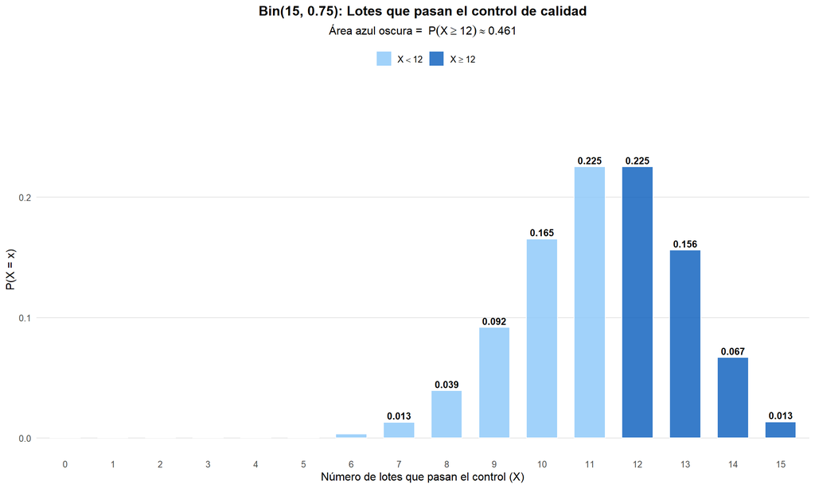

## Tu turno: Distribución Binomial

**Tu turno**

**Ejercicio 1.** Se analizan **10 muestras de suelo** de forma independiente, cada una con probabilidad $p=0.30$ de exceder un umbral de metales pesados. Sea $X$ = número de muestras que exceden el umbral.

Calcula $P(X=3)$, $P(X\leq 2)$, $E[X]$ y $Var(X)$.

**Ejercicio 2.** De **12 plantas** de una especie, cada una florece esta temporada con probabilidad $p=0.60$, independientemente. Sea $X$ = número de plantas que florecen.

Calcula $P(X=8)$ y $P(X \geq 10)$.

## Solución

**Ejercicio 1:** $X \sim \text{Bin}(10, 0.30)$

$$P(X=3) \approx \mathbf{0.267} \qquad P(X\leq 2) \approx \mathbf{0.383}$$

$$E[X]=3 \qquad Var(X)=2.1$$

**Ejercicio 2:** $X \sim \text{Bin}(12, 0.60)$

$$P(X=8) \approx \mathbf{0.213} \qquad P(X \geq 10) \approx \mathbf{0.083}$$

```r
dbinom(3, 10, 0.30); pbinom(2, 10, 0.30)
```

```
[1] 0.2668279
```

```
[1] 0.3827828
```

```r
dbinom(8, 12, 0.60); 1 - pbinom(9, 12, 0.60)
```

```
[1] 0.2128409
```

```
[1] 0.08344332
```

## Distribución Hipergeométrica

### Definición

Describe el número de éxitos al extraer $n$ elementos **sin reposición** de una población finita de $N$ elementos, de los cuales $K$ son del tipo de interés.

$$X \sim \text{Hiper}(N, K, n)$$

### Función de probabilidad

$$\boxed{p(x) = \frac{\binom{K}{x}\binom{N-K}{n-x}}{\binom{N}{n}}, \quad x = \max(0, n+K-N), \ldots, \min(n, K)}$$

### Parámetros

$$E[X] = n \cdot \frac{K}{N} \qquad Var(X) = n \cdot \frac{K}{N} \cdot \frac{N-K}{N} \cdot \frac{N-n}{N-1}$$

> El factor $\dfrac{N-n}{N-1}$ se llama **factor de corrección por población finita** y refleja que al no haber reposición, la varianza es menor que en la Binomial.

### Ejemplo experimental: Selección de muestras para reanálisis

Un lote contiene **20 muestras**, de las cuales **8 están contaminadas**. Se seleccionan al azar **6 muestras** para un análisis confirmatorio.

Sea $X$ = número de muestras contaminadas seleccionadas.

$$X \sim \text{Hiper}(N=20,\; K=8,\; n=6)$$

$$P(X = 2) = \frac{\binom{8}{2}\binom{12}{4}}{\binom{20}{6}} = \frac{28 \times 495}{38760} \approx 0.357$$

$$E[X] = 6 \cdot \frac{8}{20} = 2.4 \quad \text{muestras contaminadas esperadas}$$

## Código R: Distribución Hipergeométrica

```r
# X ~ Hiper(N=20, K=8, n=6): muestras contaminadas seleccionadas
# dhyper(x, m, n, k): m=éxitos, n=fracasos, k=extraídos

# P(X = 2): exactamente 2 muestras contaminadas seleccionadas
dhyper(x = 2, m = 8, n = 12, k = 6)
```

```
[1] 0.3575851
```

```r
# P(X <= 3): a lo sumo 3 muestras contaminadas
phyper(q = 3, m = 8, n = 12, k = 6)
```

```
[1] 0.8627451
```

```r
# P(X >= 4): al menos 4 muestras contaminadas
1 - phyper(q = 3, m = 8, n = 12, k = 6)
```

```
[1] 0.1372549
```

```r
# Valor esperado
6 * 8/20
```

```
[1] 2.4
```

## Tu turno: Distribución Hipergeométrica

**Tu turno**

**Ejercicio 1.** De **15 muestras de roca**, **5 contienen cuarzo**. Se seleccionan **4 al azar sin reposición**. Sea $X$ = número de muestras con cuarzo seleccionadas.

Calcula $P(X=2)$ y $E[X]$.

**Ejercicio 2.** En una placa con **25 colonias bacterianas**, **10 son resistentes** a un antibiótico. Se seleccionan **5 colonias** para analizar. Sea $X$ = número de colonias resistentes seleccionadas.

Calcula $P(X=3)$ y $P(X \geq 1)$.

## Solución

**Ejercicio 1:** $X \sim \text{Hiper}(N=15, K=5, n=4)$

$$P(X=2) \approx \mathbf{0.330} \qquad E[X] = 4 \cdot \frac{5}{15} \approx \mathbf{1.33}$$

**Ejercicio 2:** $X \sim \text{Hiper}(N=25, K=10, n=5)$

$$P(X=3) \approx \mathbf{0.237} \qquad P(X \geq 1) = 1 - P(X=0) \approx \mathbf{0.943}$$

```r
dhyper(x = 2, m = 5, n = 10, k = 4)
```

```
[1] 0.3296703
```

```r
dhyper(x = 3, m = 10, n = 15, k = 5)
```

```
[1] 0.2371542
```

```r
1 - dhyper(x = 0, m = 10, n = 15, k = 5)
```

```
[1] 0.9434783
```

## Distribución de Poisson

### Definición

Modela el número de **eventos** que ocurren en un intervalo de tiempo o espacio determinado, cuando los eventos ocurren a tasa constante e independientemente entre sí.

$$X \sim \text{Poisson}(\lambda)$$

### Función de probabilidad

$$\boxed{p(x) = \frac{e^{-\lambda}\, \lambda^x}{x!}, \quad x = 0, 1, 2, \ldots}$$

### Parámetros

$$\boxed{E[X] = \lambda \qquad Var(X) = \lambda}$$

> Una característica única: **media = varianza = $\lambda$**.

### Condiciones de aplicación en ciencias experimentales

- Número de **colonias bacterianas** por placa de cultivo
- Número de **partículas contaminantes** por muestra de agua
- Casos de una **mutación rara** en una población de organismos por generación
- Número de **defectos** por lote de producción
- Llamadas al **servicio de mantenimiento de equipos** por noche

### Ejemplo: Colonias bacterianas por placa

En un laboratorio de microbiología, el promedio de colonias bacterianas que crecen por placa de cultivo es de **$\lambda = 4$ colonias**. Sea $X$ el número de colonias en una placa.

$$X \sim \text{Poisson}(4)$$

$$P(X = 6) = \frac{e^{-4} \cdot 4^6}{6!} = \frac{0.0183 \times 4096}{720} \approx 0.104$$

$$P(X \leq 2) = \sum_{x=0}^{2} \frac{e^{-4} \cdot 4^x}{x!} = e^{-4}(1 + 4 + 8) = 0.238$$

## Código R: Distribución de Poisson

```r
# X ~ Poi(4): colonias bacterianas por placa
# P(X = 6): exactamente 6 colonias
dpois(x = 6, lambda = 4)
```

```
[1] 0.1041956
```

```r
# P(X <= 2): a lo sumo 2 colonias (placa poco contaminada)
ppois(q = 2, lambda = 4)
```

```
[1] 0.2381033
```

```r
# P(X >= 7): 7 o más colonias (placa muy contaminada)
1 - ppois(q = 6, lambda = 4)
```

```
[1] 0.110674
```

```r
# Percentil 95: valor que no se supera el 95% del tiempo
qpois(p = 0.95, lambda = 4)
```

```
[1] 8
```